# Indiana Feeding Rate Assays

Meghan Duffy

October 27, 2016

# Does feeding rate differ before and after epidemics?

Data collection for this project led by Katie Hunsberger (technician in Duffy Lab), using clones sent from Spencer Hall’s lab in Indiana. Data analysis led by Meghan Duffy (duffymeg@umich.edu)

Right now, data sheet just has Island data in it. Will need to update this with rest of data, but starting with this as a trial.

Note about data: The fluorometer drifts over time. We quantify this by running controls periodically. We then need to factor out this drift to determine how the baseline RFUs for an ungrazed tube shifts over time.

## Jenny Bryan’s (elegant!) proposal for dealing with fluorometer drift issue

Read data in.

```r
df <- read.csv("indianafeedingrateassays_withcontrols.csv", na.strings = ".")
df$Block <- factor(df$Block)
head(df)
```

```
#>     Lake Block CloneSubline Rep     RFU length_um length_mm order prepost
#> 1 Island     1         1-9A   1 6344.30   1105.01   1.10501     7     pre
#> 2 Island     1         1-9A   2 6455.30   1264.50   1.26450     8     pre
#> 3 Island     1         1-9A   3 5821.09   1150.00   1.15000     9     pre
#> 4 Island     1         1-9A   4 5922.55   1298.60   1.29860    10     pre
#> 5 Island     1         1-9A   5 6591.87   1218.15   1.21815    11     pre
#> 6 Island     1       10-37A   1 5975.83   1209.47   1.20947   121     pre
```

```r
str(df)
```

```
#> 'data.frame':    265 obs. of  9 variables:
#>  $ Lake        : Factor w/ 1 level "Island": 1 1 1 1 1 1 1 1 1 1 ...
#>  $ Block       : Factor w/ 2 levels "1","2": 1 1 1 1 1 1 1 1 1 1 ...
#>  $ CloneSubline: Factor w/ 55 levels "1-9A","10-37A",..: 1 1 1 1 1 2 2 2 2 2 ...
#>  $ Rep         : int  1 2 3 4 5 1 2 3 4 5 ...
#>  $ RFU         : num  6344 6455 5821 5923 6592 ...
#>  $ length_um   : num  1105 1264 1150 1299 1218 ...
#>  $ length_mm   : num  1.11 1.26 1.15 1.3 1.22 ...
#>  $ order       : int  7 8 9 10 11 121 122 123 124 125 ...
#>  $ prepost     : Factor w/ 4 levels "control","post",..: 3 3 3 3 3 3 3 3 3 3 ...
```

For the controls only, plot RFU against order and color by Block. Add a fitted line for each Block.

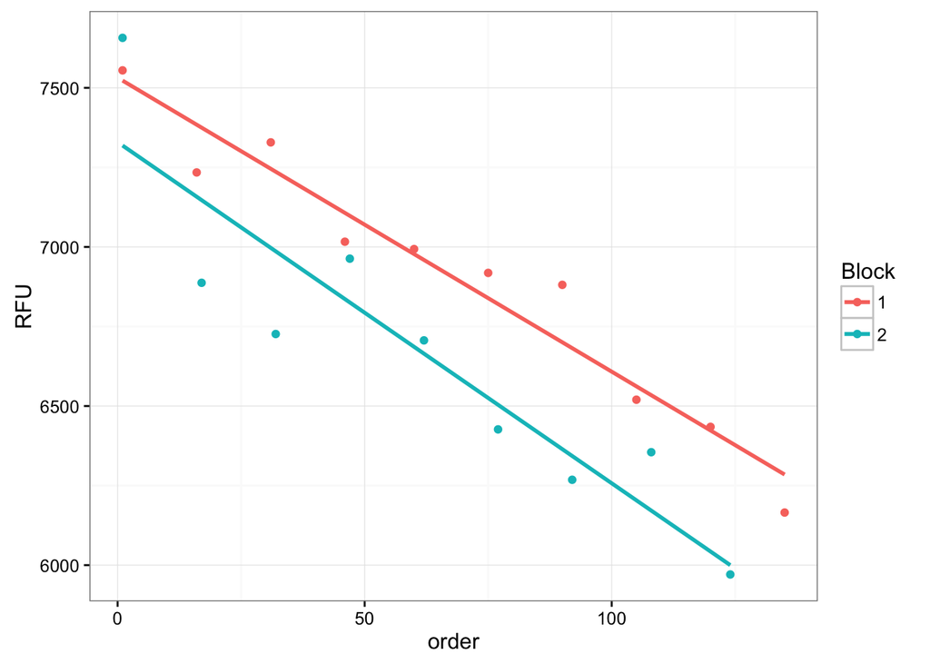

```r
df %>%
  filter(CloneSubline == "Control") %>%
  ggplot(aes(x = order, y = RFU, color = Block)) +
  geom_point() +
  geom_smooth(method = "lm", se = FALSE) +
  theme_bw()
```

Regress RFU on order within Block, for the controls. Eyeball-o-metrically check the intercept and slope against the plot.

```r
control_fit <- lm(RFU ~ Block/order - 1, data = df,
                  subset = CloneSubline == "Control")
summary(control_fit)
```

```
#>
#> Call:
#> lm(formula = RFU ~ Block/order - 1, data = df, subset = CloneSubline ==
#>     "Control")
#>
#> Residuals:
#>     Min      1Q  Median      3Q     Max
#> -259.97  -83.89   11.24   81.23  338.41
#>
#> Coefficients:
#>              Estimate Std. Error t value Pr(>|t|)
#> Block1       7532.003     98.293  76.628  < 2e-16 ***
#> Block2       7329.393    103.085  71.100  < 2e-16 ***
#> Block1:order   -9.239      1.226  -7.538 1.78e-06 ***
#> Block2:order  -10.721      1.400  -7.658 1.47e-06 ***
#> ---
#> Signif. codes:  0 '***' 0.001 '**' 0.01 '*' 0.05 '.' 0.1 ' ' 1
#>
#> Residual standard error: 165.4 on 15 degrees of freedom
#> Multiple R-squared:  0.9995, Adjusted R-squared:  0.9994
#> F-statistic:  8038 on 4 and 15 DF,  p-value: < 2.2e-16
```

Add a variable into `df` for the predicted RFU of a control tube; this tells us what RFUs we’d expect if there was no Daphnia in a tube (or if the Daphnia didn’t eat anything)

```r
df$predictedControlRFU <-
  predict(control_fit, newdata = df[c("order", "Block")])
head(df)
```

```
#>     Lake Block CloneSubline Rep     RFU length_um length_mm order prepost
#> 1 Island     1         1-9A   1 6344.30   1105.01   1.10501     7     pre
#> 2 Island     1         1-9A   2 6455.30   1264.50   1.26450     8     pre
#> 3 Island     1         1-9A   3 5821.09   1150.00   1.15000     9     pre
#> 4 Island     1         1-9A   4 5922.55   1298.60   1.29860    10     pre
#> 5 Island     1         1-9A   5 6591.87   1218.15   1.21815    11     pre
#> 6 Island     1       10-37A   1 5975.83   1209.47   1.20947   121     pre
#>   predictedControlRFU
#> 1            7467.328
#> 2            7458.089
#> 3            7448.849
#> 4            7439.610
#> 5            7430.370
#> 6            6414.041
```

Now use that to calculate the clearance rate (which we also call feeding rate, because “clearance” has a different meaning to disease ecologists, and so can be a confusing term). Also need to know that the assays were run for 3 hours (0.125 days) and in 15 mL (0.015 L) water.

```r
df <-
  mutate(df, CR = log(predictedControlRFU/RFU)*0.015*0.125)
head(df)
```

```
#>     Lake Block CloneSubline Rep     RFU length_um length_mm order prepost
#> 1 Island     1         1-9A   1 6344.30   1105.01   1.10501     7     pre
#> 2 Island     1         1-9A   2 6455.30   1264.50   1.26450     8     pre
#> 3 Island     1         1-9A   3 5821.09   1150.00   1.15000     9     pre
#> 4 Island     1         1-9A   4 5922.55   1298.60   1.29860    10     pre
#> 5 Island     1         1-9A   5 6591.87   1218.15   1.21815    11     pre
#> 6 Island     1       10-37A   1 5975.83   1209.47   1.20947   121     pre
#>   predictedControlRFU           CR
#> 1            7467.328 0.0003055883
#> 2            7458.089 0.0002707456
#> 3            7448.849 0.0004623225
#> 4            7439.610 0.0004275962
#> 5            7430.370 0.0002245100
#> 6            6414.041 0.0001326872
```

Now calculate the size-specific clearance rate

```r
df <-
  mutate(df, SSCR = CR/(length_mm)^2)
head(df)
```

```
#>     Lake Block CloneSubline Rep     RFU length_um length_mm order prepost
#> 1 Island     1         1-9A   1 6344.30   1105.01   1.10501     7     pre
#> 2 Island     1         1-9A   2 6455.30   1264.50   1.26450     8     pre
#> 3 Island     1         1-9A   3 5821.09   1150.00   1.15000     9     pre
#> 4 Island     1         1-9A   4 5922.55   1298.60   1.29860    10     pre
#> 5 Island     1         1-9A   5 6591.87   1218.15   1.21815    11     pre
#> 6 Island     1       10-37A   1 5975.83   1209.47   1.20947   121     pre
#>   predictedControlRFU           CR         SSCR
#> 1            7467.328 0.0003055883 2.502674e-04
#> 2            7458.089 0.0002707456 1.693260e-04
#> 3            7448.849 0.0004623225 3.495823e-04
#> 4            7439.610 0.0004275962 2.535613e-04
#> 5            7430.370 0.0002245100 1.512983e-04
#> 6            6414.041 0.0001326872 9.070659e-05
```

Check to make sure there don’t seem to be major trends in the clearance rates over the course of the assay

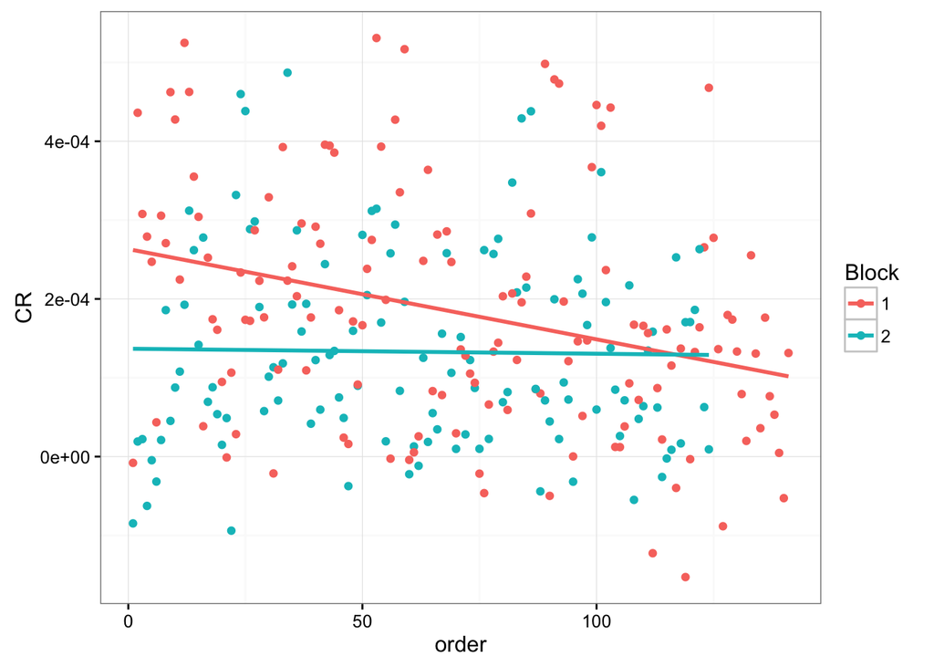

```r
df %>%
  ggplot(aes(x = order, y = CR, color = Block)) +
  geom_point() +
  geom_smooth(method = "lm", se = FALSE) +
  theme_bw()
```

Hrm, something looks not right with block 1. Will need to look into that more. First check: is something going wrong with the predictions? Testing this by subsetting the data so there’s just one block.

```r
testdf <- read.csv("indianafeedingrateassays_withcontrols.csv", na.strings = ".")
testdf$Block <- factor(testdf$Block)
testdf <- subset(testdf, Block == 1)
tail(testdf)
```

```
#>       Lake Block CloneSubline Rep     RFU length_um length_mm order
#> 246 Island     1      Control  10 6165.30        NA        NA   135
#> 256 Island     1         StdA   1 5144.22   1327.82   1.32782    89
#> 257 Island     1         StdA   2 5184.20   1292.57   1.29257    91
#> 258 Island     1         StdA   3 5191.68   1325.77   1.32577    92
#> 261 Island     1         StdB   1 6008.22   1198.44   1.19844    93
#> 262 Island     1         StdB   2 6246.76   1161.68   1.16168    94
#>     prepost
#> 246 control
#> 256     std
#> 257     std
#> 258     std
#> 261     std
#> 262     std
```

```r
control_fit2 <- lm(RFU ~ order, data = testdf,
                  subset = CloneSubline == "Control")
summary(control_fit2)
```

```
#>
#> Call:
#> lm(formula = RFU ~ order, data = testdf, subset = CloneSubline ==
#>     "Control")
#>
#> Residuals:
#>     Min      1Q  Median      3Q     Max
#> -150.02  -78.40   13.43   67.58  180.45
#>
#> Coefficients:
#>              Estimate Std. Error t value Pr(>|t|)
#> (Intercept) 7532.0034    64.3879  116.98 3.19e-14 ***
#> order         -9.2394     0.8029  -11.51 2.95e-06 ***
#> ---
#> Signif. codes:  0 '***' 0.001 '**' 0.01 '*' 0.05 '.' 0.1 ' ' 1
#>
#> Residual standard error: 108.3 on 8 degrees of freedom
#> Multiple R-squared:  0.943,  Adjusted R-squared:  0.9359
#> F-statistic: 132.4 on 1 and 8 DF,  p-value: 2.949e-06
```

```r
testdf$predictedControlRFU <-
  predict(control_fit2, newdata = testdf[c("order", "Block")])
head(testdf)
```

```
#>     Lake Block CloneSubline Rep     RFU length_um length_mm order prepost
#> 1 Island     1         1-9A   1 6344.30   1105.01   1.10501     7     pre
#> 2 Island     1         1-9A   2 6455.30   1264.50   1.26450     8     pre
#> 3 Island     1         1-9A   3 5821.09   1150.00   1.15000     9     pre
#> 4 Island     1         1-9A   4 5922.55   1298.60   1.29860    10     pre
#> 5 Island     1         1-9A   5 6591.87   1218.15   1.21815    11     pre
#> 6 Island     1       10-37A   1 5975.83   1209.47   1.20947   121     pre
#>   predictedControlRFU
#> 1            7467.328
#> 2            7458.089
#> 3            7448.849
#> 4            7439.610
#> 5            7430.370
#> 6            6414.041
```

```r
testdf <-
  mutate(testdf, CR = log(predictedControlRFU/RFU)*0.015*0.125)
head(testdf)
```

```
#>     Lake Block CloneSubline Rep     RFU length_um length_mm order prepost
#> 1 Island     1         1-9A   1 6344.30   1105.01   1.10501     7     pre
#> 2 Island     1         1-9A   2 6455.30   1264.50   1.26450     8     pre
#> 3 Island     1         1-9A   3 5821.09   1150.00   1.15000     9     pre
#> 4 Island     1         1-9A   4 5922.55   1298.60   1.29860    10     pre
#> 5 Island     1         1-9A   5 6591.87   1218.15   1.21815    11     pre
#> 6 Island     1       10-37A   1 5975.83   1209.47   1.20947   121     pre
#>   predictedControlRFU           CR
#> 1            7467.328 0.0003055883
#> 2            7458.089 0.0002707456
#> 3            7448.849 0.0004623225
#> 4            7439.610 0.0004275962
#> 5            7430.370 0.0002245100
#> 6            6414.041 0.0001326872
```

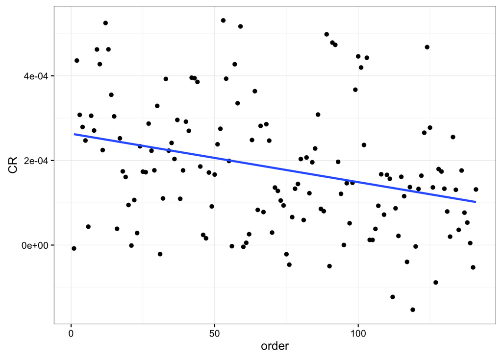

```r
testdf %>%
  ggplot(aes(x = order, y = CR)) +
  geom_point() +
  geom_smooth(method = "lm", se = FALSE) +
  theme_bw()
```

Okay. It’s not just a problem with calculating predicted RFUs. Will need to figure out whether we should do anything about this later. The first step might be seeing if it happened in the blocks for other lakes, too.

## Looking at data for different genotypes and sublines

First step: separate clone and subline (which are currently merged into the “CloneSubline” variable)

```r
dfnc <- subset(df,CloneSubline != "Control")
dfnc$CloneSubline <- as.character(dfnc$CloneSubline)
dfnc$Subline <- str_sub(dfnc$CloneSubline,-1,length(dfnc$CloneSubline))
dfnc$Clone <- substr(dfnc$CloneSubline, 1, nchar(dfnc$CloneSubline)-1)
dfnc$Subline
```

```
#>   [1] "A" "A" "A" "A" "A" "A" "A" "A" "A" "A" "B" "B" "B" "B" "B" "B" "B"
#>  [18] "B" "B" "B" "A" "A" "A" "A" "A" "B" "B" "B" "B" "B" "A" "A" "A" "A"
#>  [35] "A" "B" "B" "B" "B" "B" "A" "A" "A" "A" "A" "A" "A" "A" "A" "A" "B"
#>  [52] "B" "B" "B" "B" "A" "A" "A" "A" "A" "B" "B" "B" "B" "B" "A" "A" "A"
#>  [69] "A" "A" "B" "B" "B" "B" "B" "A" "A" "A" "A" "A" "B" "B" "B" "A" "A"
#>  [86] "A" "A" "A" "B" "B" "B" "B" "B" "A" "A" "A" "A" "A" "B" "B" "B" "B"
#> [103] "B" "B" "B" "B" "B" "B" "B" "A" "A" "A" "A" "A" "A" "A" "B" "B" "B"
#> [120] "B" "B" "A" "A" "A" "A" "B" "A" "A" "A" "A" "A" "A" "A" "A" "A" "A"
#> [137] "B" "B" "B" "B" "B" "A" "A" "A" "A" "B" "B" "B" "B" "B" "B" "B" "B"
#> [154] "B" "B" "A" "A" "A" "A" "A" "B" "B" "B" "B" "B" "A" "A" "A" "A" "A"
#> [171] "B" "B" "B" "A" "A" "A" "A" "A" "B" "B" "B" "B" "B" "A" "A" "A" "A"
#> [188] "A" "B" "B" "B" "B" "B" "A" "A" "A" "A" "A" "B" "B" "B" "B" "B" "A"
#> [205] "A" "A" "A" "A" "B" "B" "B" "B" "B" "B" "B" "B" "A" "A" "A" "A" "A"
#> [222] "B" "B" "B" "B" "B" "A" "A" "A" "A" "A" "B" "B" "B" "B" "B" "A" "A"
#> [239] "A" "A" "A" "B" "B" "B" "B" "B"
```

```r
dfnc$Clone
```

```
#>   [1] "1-9"   "1-9"   "1-9"   "1-9"   "1-9"   "10-37" "10-37" "10-37"
#>   [9] "10-37" "10-37" "10-37" "10-37" "10-37" "10-37" "10-37" "13-41"
#>  [17] "13-41" "13-41" "13-41" "13-41" "14"    "14"    "14"    "14"
#>  [25] "14"    "14"    "14"    "14"    "14"    "14"    "17"    "17"
#>  [33] "17"    "17"    "17"    "17"    "17"    "17"    "17"    "17"
#>  [41] "19"    "19"    "19"    "19"    "19"    "20-64" "20-64" "20-64"
#>  [49] "20-64" "20-64" "20-64" "20-64" "20-64" "20-64" "20-64" "20"
#>  [57] "20"    "20"    "20"    "20"    "20"    "20"    "20"    "20"
#>  [65] "20"    "21-65" "21-65" "21-65" "21-65" "21-65" "21-65" "21-65"
#>  [73] "21-65" "21-65" "21-65" "24-69" "24-69" "24-69" "24-69" "24-69"
#>  [81] "24-69" "24-69" "24-69" "25-72" "25-72" "25-72" "25-72" "25-72"
#>  [89] "25-72" "25-72" "25-72" "25-72" "25-72" "26-77" "26-77" "26-77"
#>  [97] "26-77" "26-77" "26-77" "26-77" "3"     "3"     "3"     "3"
#> [105] "3"     "4-13"  "4-13"  "4-13"  "4-13"  "5-14"  "5-14"  "52"
#> [113] "52"    "54"    "54"    "54"    "54"    "54"    "54"    "54"
```

[output cut: 16 more lines]

Then, figure out the mean among the different replicates for each clone*subline combination Seeing if I can figure out how to graph it first

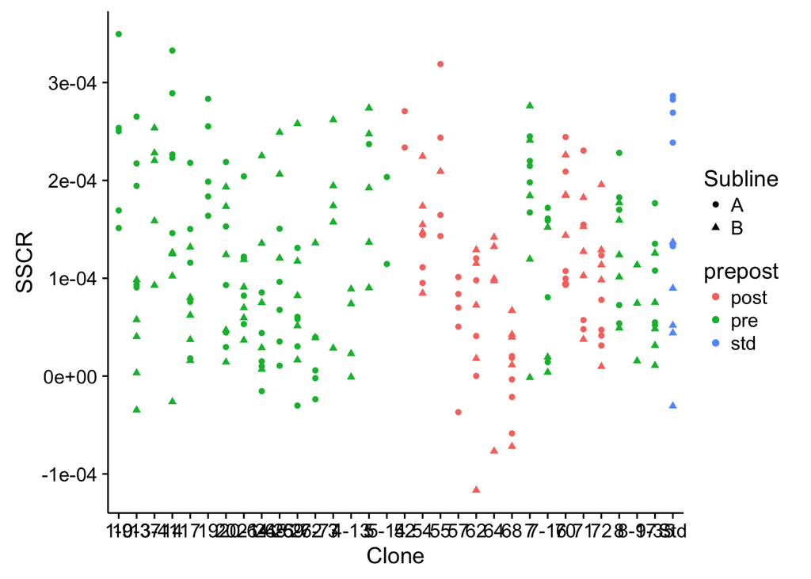

```r
ggplot(dfnc,aes(x=Clone,y=SSCR)) +
  geom_point(aes(color=prepost,shape=Subline))
```

Calculating one value for each clone; first, calculating a mean for each clone-subline combination, then averaging those two values to get one for each clone.

```r
meanbysublineSSCR <- dfnc %>%
  subset(!is.na(SSCR)) %>%
  group_by(Clone,Subline,prepost) %>%
  summarise(avg=mean(SSCR))

meanbycloneSSCR <- meanbysublineSSCR %>%
  group_by(Clone,prepost) %>%
  summarise(avg=mean(avg))

meanbysublineCR <- dfnc %>%
  subset(!is.na(CR)) %>%
  group_by(Clone,Subline,prepost) %>%
  summarise(avg=mean(CR))

meanbycloneCR <- meanbysublineCR %>%
  group_by(Clone,prepost) %>%
  summarise(avg=mean(avg))

meanbysublinelength <- dfnc %>%
  subset(!is.na(length_mm)) %>%
  group_by(Clone,Subline,prepost) %>%
  summarise(avg=mean(length_mm))

meanbyclonelength <- meanbysublinelength %>%
  group_by(Clone,prepost) %>%
  summarise(avg=mean(avg))
```

Plotting the means

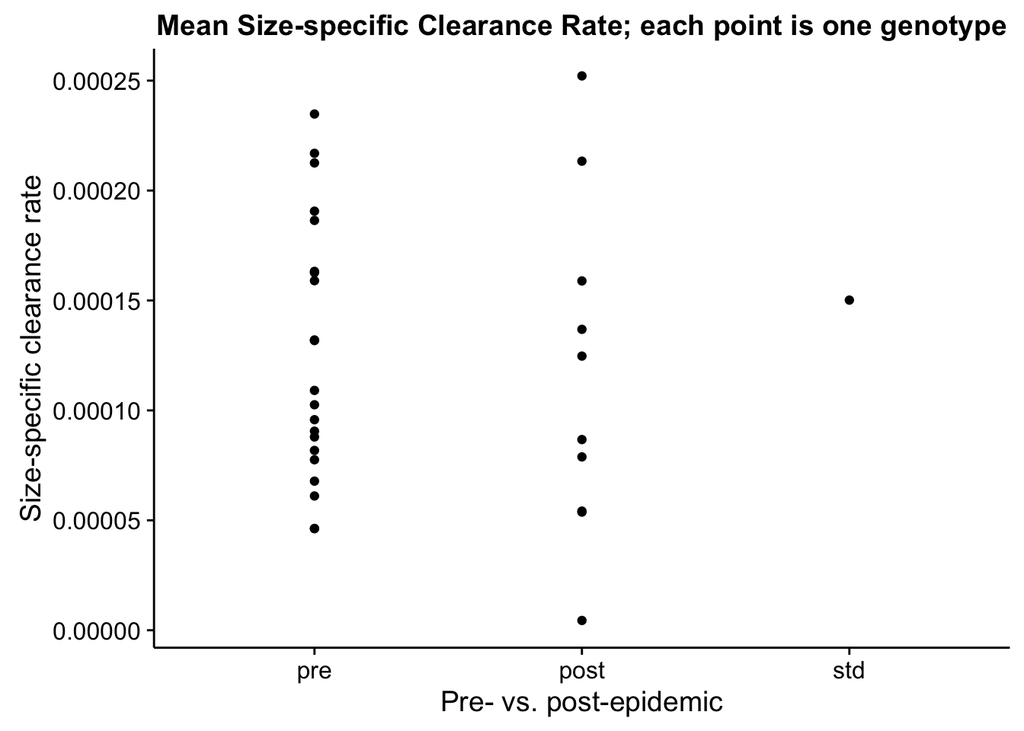

```r
ggplot(meanbycloneSSCR,aes(x=prepost,y=avg)) +
  geom_point() +
  ylab("Size-specific clearance rate") +
  ggtitle("Mean Size-specific Clearance Rate; each point is one genotype") +
  scale_x_discrete(limits=c("pre", "post", "std")) +
  xlab("Pre- vs. post-epidemic")
```

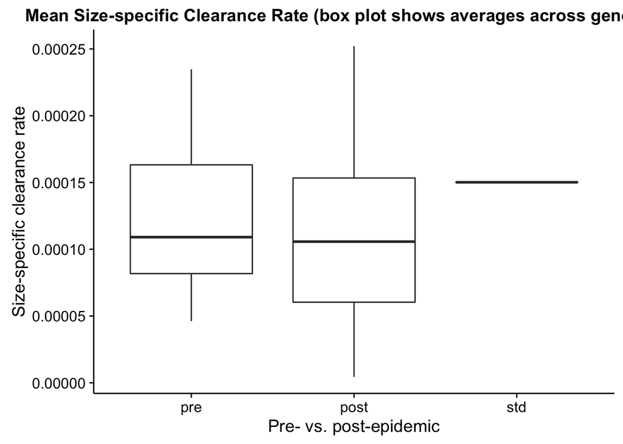

```r
ggplot(meanbycloneSSCR,aes(x=prepost,y=avg)) +
  geom_boxplot() +
  ylab("Size-specific clearance rate") +
  ggtitle("Mean Size-specific Clearance Rate (box plot shows averages across genotypes)") +
  scale_x_discrete(limits=c("pre", "post", "std")) +
  xlab("Pre- vs. post-epidemic")
```

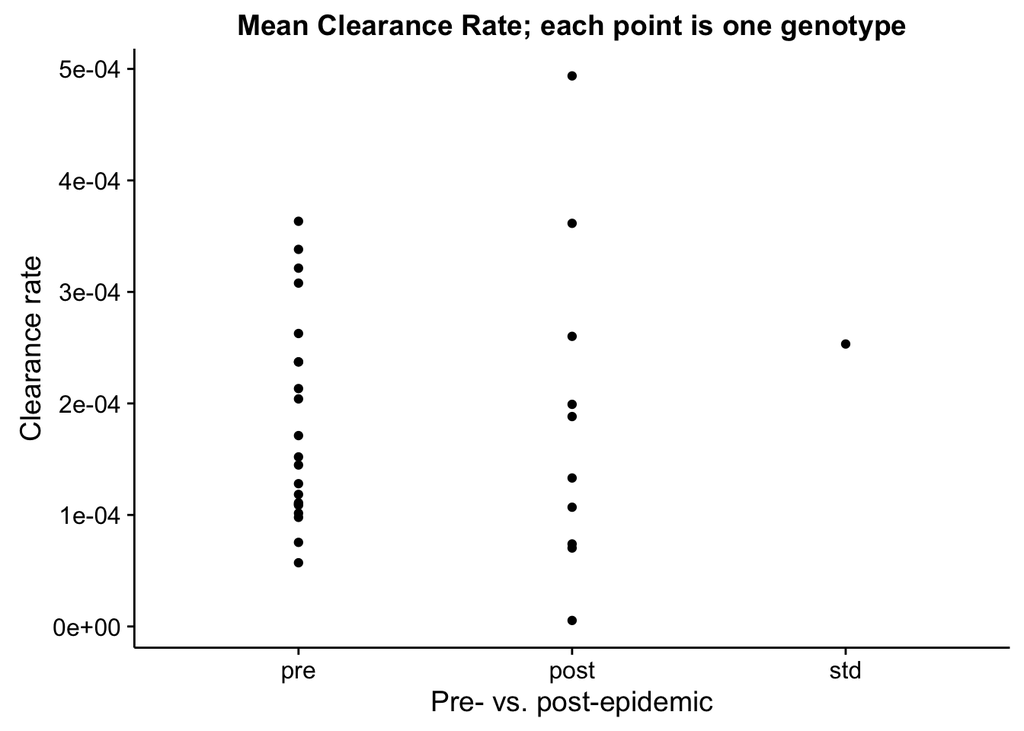

```r
ggplot(meanbycloneCR,aes(x=prepost,y=avg)) +
  geom_point() +
  ylab("Clearance rate") +
  ggtitle("Mean Clearance Rate; each point is one genotype") +
  scale_x_discrete(limits=c("pre", "post", "std")) +
  xlab("Pre- vs. post-epidemic")
```

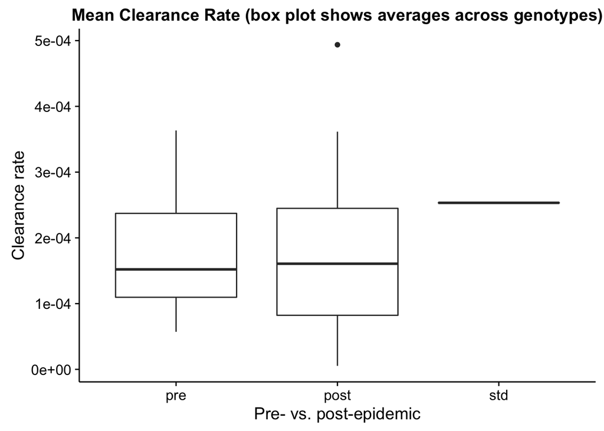

```r
ggplot(meanbycloneCR,aes(x=prepost,y=avg)) +
  geom_boxplot() +
  ylab("Clearance rate") +
  ggtitle("Mean Clearance Rate (box plot shows averages across genotypes)") +
  scale_x_discrete(limits=c("pre", "post", "std")) +
  xlab("Pre- vs. post-epidemic")
```

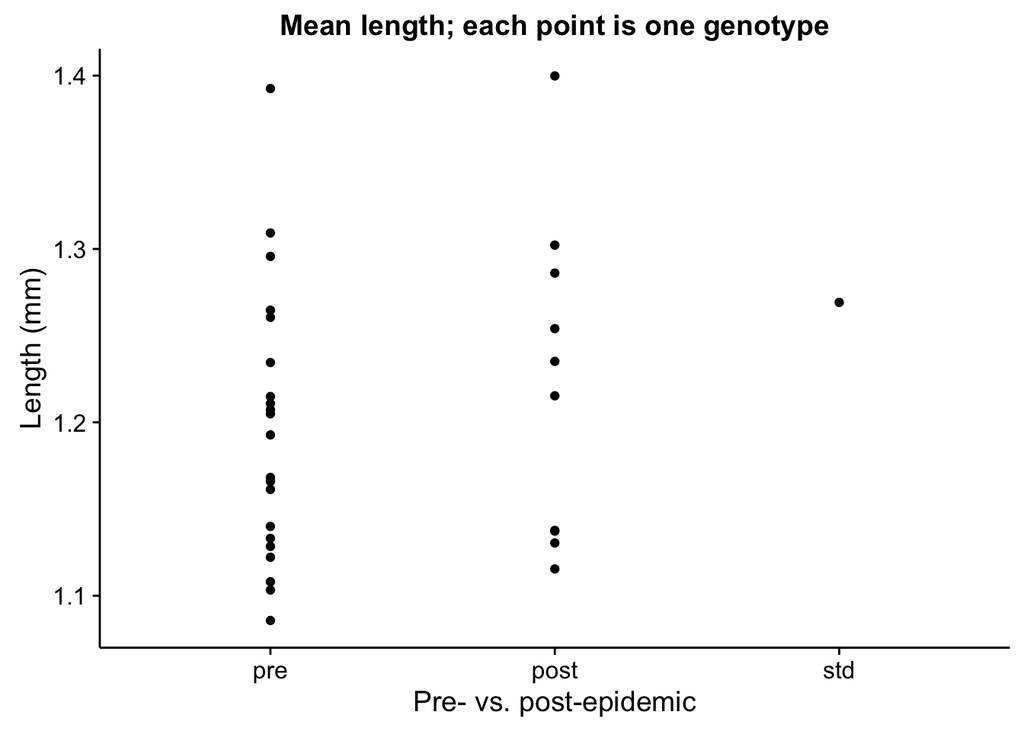

```r
ggplot(meanbyclonelength,aes(x=prepost,y=avg)) +
  geom_point() +
  ylab("Length (mm)") +
  ggtitle("Mean length; each point is one genotype") +
  scale_x_discrete(limits=c("pre", "post", "std")) +
  xlab("Pre- vs. post-epidemic")
```

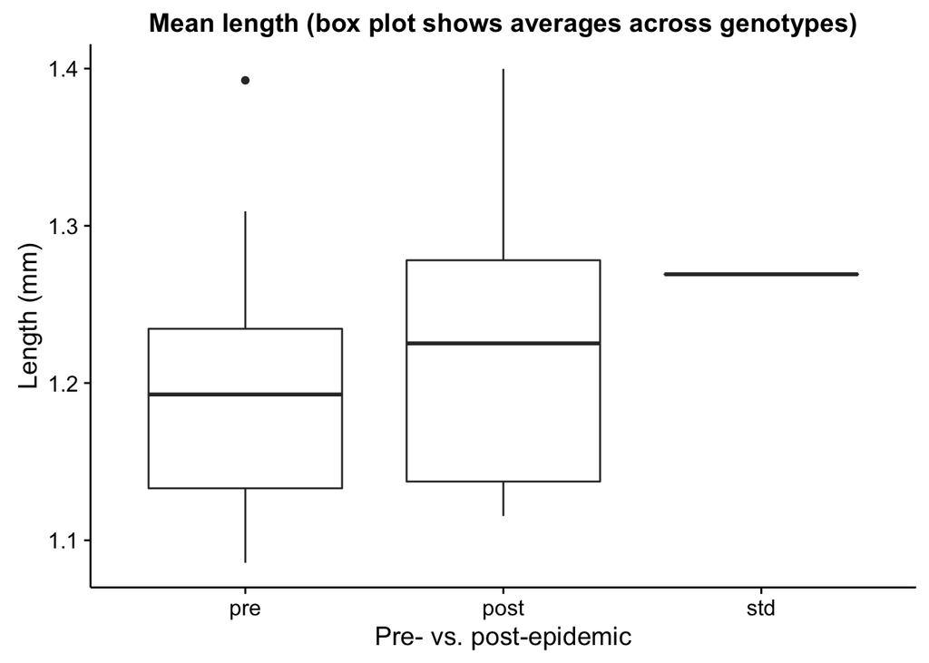

```r
ggplot(meanbyclonelength,aes(x=prepost,y=avg)) +
  geom_boxplot() +
  ylab("Length (mm)") +
  ggtitle("Mean length (box plot shows averages across genotypes)") +
  scale_x_discrete(limits=c("pre", "post", "std")) +
  xlab("Pre- vs. post-epidemic")
```

To do next: analyze evolution, looking for changes in mean and/or variance